# Constructing a DAG for the impact of DOC on Anoxic Duration Under Ice

Katie Gannon

2025-02-26

# Project Overview

*Katie Comment:* I study lakes and for one of my projects I am interested in the processes happening under lake ice in winter. I will be using this exercise to explore how the amount of organic matter (measured as the concentration of dissolved organic carbon or DOC) in the water of a lake in the fall impacts the duration of anoxia (no oxygen) in bottom waters of mountain lakes.

# Create DAG

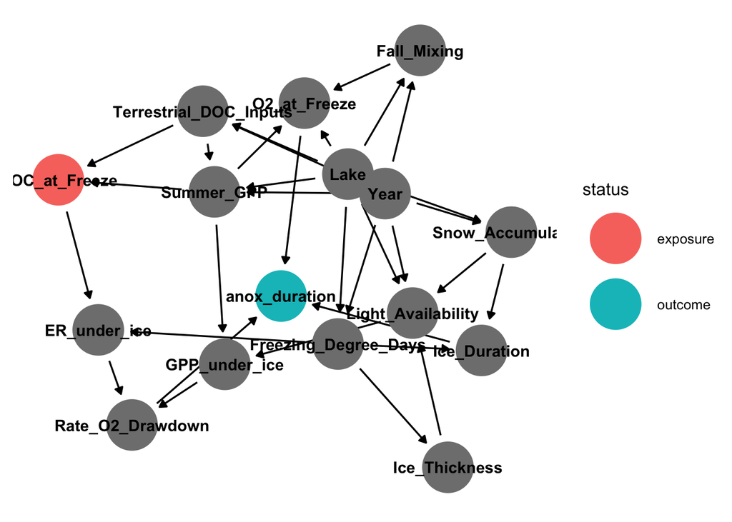

```r
# Create DAG

    DAG_oxygen_under_ice <- dagify(

      #Identify Relatiobships
      anox_duration ~ O2_at_Freeze + Ice_Duration + Rate_O2_Drawdown,
      Rate_O2_Drawdown ~ ER_under_ice + GPP_under_ice,
      ER_under_ice ~ Freezing_Degree_Days + DOC_at_Freeze,
      DOC_at_Freeze ~ Terrestrial_DOC_Inputs + Summer_GPP,
      GPP_under_ice ~ Summer_GPP + Light_Availability,
      Light_Availability ~ Snow_Accumulation + Ice_Thickness + Lake + Year,
      Ice_Thickness ~ Freezing_Degree_Days,
      Ice_Duration ~ Freezing_Degree_Days + Snow_Accumulation,
      O2_at_Freeze ~ Summer_GPP + Lake + Fall_Mixing,
      Summer_GPP~ Terrestrial_DOC_Inputs + Lake + Year,
      Freezing_Degree_Days ~ Lake + Year,
      Snow_Accumulation ~ Lake + Year,
      Terrestrial_DOC_Inputs ~ Lake + Year,
      Fall_Mixing ~ Lake + Year,

      # Specify exposure and outcome
      exposure = "DOC_at_Freeze",
      outcome = "anox_duration",

      # Label
      labels = c(outcome = "Annoxic Duration",
                 exposure = "DOC at Lake Freeze "))


# Visualize DAG
set.seed(124) #set the seed when plotting because otherwise the DAG shows up in different orientations each time!

ggdag_status(DAG_oxygen_under_ice,
             use_labels = "label",
             text = TRUE,
              text_col = "black",
             label_alpha = 0.5) + theme_dag()
```

*Katie Comment:* The main updates that I have made are adding Lake and Year variables to my DAG (because I expect both of those variables to impact both my exposure and my impact variables) and thinking about the timescale of my variables. I realized that there was s disconnect because I was comparing some variables that were rates, some variables that had discrete measurements at individual timepoints, and some variables that were seasonal totals or averages. Those time steps made it tricky as I tried to think about how to account for more climate and seasonal variables. To deal with this disconnect, I shifted all of my variables to be either an descrete measure before the season of interest or an average/max across the season.

#Identify Paths This function takes a DAG, with a given “exposure” or “treatment variable” and an “outcome” and identifies open backdoors: confounding variables (common causes) that need to be controlled for.

```r
#identify the open paths that need to be adjusted for
paths(DAG_oxygen_under_ice)
```

```
## $paths
##   [1] "DOC_at_Freeze -> ER_under_ice -> Rate_O2_Drawdown -> anox_duration"
##   [2] "DOC_at_Freeze -> ER_under_ice -> Rate_O2_Drawdown <- GPP_under_ice <- Light_Availability <- Ice_Thickness <- Freezing_Degree_Days -> Ice_Duration -> anox_duration"
##   [3] "DOC_at_Freeze -> ER_under_ice -> Rate_O2_Drawdown <- GPP_under_ice <- Light_Availability <- Ice_Thickness <- Freezing_Degree_Days -> Ice_Duration <- Snow_Accumulation <- Lake -> Fall_Mixing -> O2_at_Freeze -> anox_duration"
##   [4] "DOC_at_Freeze -> ER_under_ice -> Rate_O2_Drawdown <- GPP_under_ice <- Light_Availability <- Ice_Thickness <- Freezing_Degree_Days -> Ice_Duration <- Snow_Accumulation <- Lake -> Fall_Mixing <- Year -> Summer_GPP -> O2_at_Freeze -> anox_duration"
##   [5] "DOC_at_Freeze -> ER_under_ice -> Rate_O2_Drawdown <- GPP_under_ice <- Light_Availability <- Ice_Thickness <- Freezing_Degree_Days -> Ice_Duration <- Snow_Accumulation <- Lake -> Fall_Mixing <- Year -> Terrestrial_DOC_Inputs -> Summer_GPP -> O2_at_Freeze -> anox_duration"
##   [6] "DOC_at_Freeze -> ER_under_ice -> Rate_O2_Drawdown <- GPP_under_ice <- Light_Availability <- Ice_Thickness <- Freezing_Degree_Days -> Ice_Duration <- Snow_Accumulation <- Lake -> O2_at_Freeze -> anox_duration"
##   [7] "DOC_at_Freeze -> ER_under_ice -> Rate_O2_Drawdown <- GPP_under_ice <- Light_Availability <- Ice_Thickness <- Freezing_Degree_Days -> Ice_Duration <- Snow_Accumulation <- Lake -> Summer_GPP -> O2_at_Freeze -> anox_duration"
##   [8] "DOC_at_Freeze -> ER_under_ice -> Rate_O2_Drawdown <- GPP_under_ice <- Light_Availability <- Ice_Thickness <- Freezing_Degree_Days -> Ice_Duration <- Snow_Accumulation <- Lake -> Summer_GPP <- Terrestrial_DOC_Inputs <- Year -> Fall_Mixing -> O2_at_Freeze -> anox_duration"
##   [9] "DOC_at_Freeze -> ER_under_ice -> Rate_O2_Drawdown <- GPP_under_ice <- Light_Availability <- Ice_Thickness <- Freezing_Degree_Days -> Ice_Duration <- Snow_Accumulation <- Lake -> Summer_GPP <- Year -> Fall_Mixing -> O2_at_Freeze -> anox_duration"
##  [10] "DOC_at_Freeze -> ER_under_ice -> Rate_O2_Drawdown <- GPP_under_ice <- Light_Availability <- Ice_Thickness <- Freezing_Degree_Days -> Ice_Duration <- Snow_Accumulation <- Lake -> Terrestrial_DOC_Inputs -> Summer_GPP -> O2_at_Freeze -> anox_duration"
##  [11] "DOC_at_Freeze -> ER_under_ice -> Rate_O2_Drawdown <- GPP_under_ice <- Light_Availability <- Ice_Thickness <- Freezing_Degree_Days -> Ice_Duration <- Snow_Accumulation <- Lake -> Terrestrial_DOC_Inputs -> Summer_GPP <- Year -> Fall_Mixing -> O2_at_Freeze -> anox_duration"
##  [12] "DOC_at_Freeze -> ER_under_ice -> Rate_O2_Drawdown <- GPP_under_ice <- Light_Availability <- Ice_Thickness <- Freezing_Degree_Days -> Ice_Duration <- Snow_Accumulation <- Lake -> Terrestrial_DOC_Inputs <- Year -> Fall_Mixing -> O2_at_Freeze -> anox_duration"
##  [13] "DOC_at_Freeze -> ER_under_ice -> Rate_O2_Drawdown <- GPP_under_ice <- Light_Availability <- Ice_Thickness <- Freezing_Degree_Days -> Ice_Duration <- Snow_Accumulation <- Lake -> Terrestrial_DOC_Inputs <- Year -> Summer_GPP -> O2_at_Freeze -> anox_duration"
##  [14] "DOC_at_Freeze -> ER_under_ice -> Rate_O2_Drawdown <- GPP_under_ice <- Light_Availability <- Ice_Thickness <- Freezing_Degree_Days -> Ice_Duration <- Snow_Accumulation <- Year -> Fall_Mixing -> O2_at_Freeze -> anox_duration"
```

[output cut: 97 more lines]

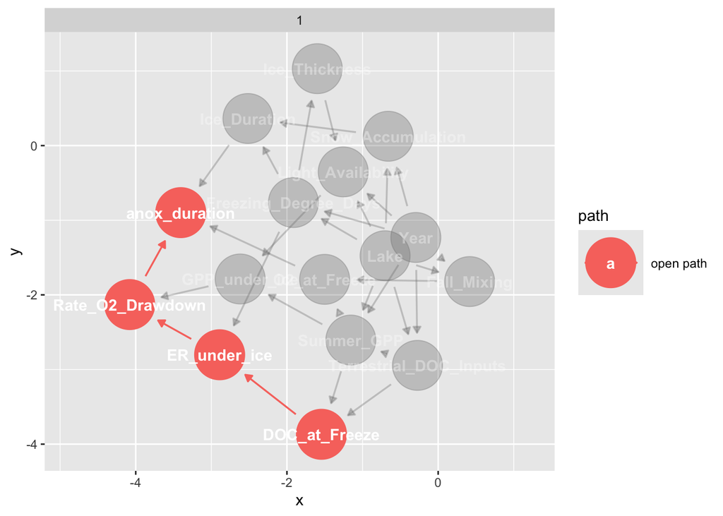

```r
#plot the open  paths (aka a mess of bubbles)
ggdag_paths(DAG_oxygen_under_ice, shadow = TRUE) #Also, do not forget to set the argument shadow = TRUE, so that the arrows from the adjusted nodes are included
```